# Ford Go Bike Data Exploration

**Name:** Michael Owusu Agyebeng\ **Description:** Udacity Student

1. Introduction
2. Data Gathering
3. Assessing data
4. Cleaning data
5. Analyzing and visualizing data

## Introduction

This document explores a dataset containing individual rides made in a bike-sharing system covering the greater San Francisco Bay area.

### Data Gathering

```python
# import all packages and set plots to be embedded inline
import numpy as np
import pandas as pd
import matplotlib.pyplot as plt
import seaborn as sb

%matplotlib inline
```

```python
# load in the dataset into a pandas dataframe
fordgobike = pd.read_csv('201902-fordgobike-tripdata.csv')
# overview of data shape and composition
print(fordgobike.shape)
print(fordgobike.dtypes)
print(fordgobike.head())
```

```
(183412, 16)
duration_sec                 int64
start_time                  object
end_time                    object
start_station_id           float64
start_station_name          object
start_station_latitude     float64
start_station_longitude    float64
end_station_id             float64
end_station_name            object
end_station_latitude       float64
end_station_longitude      float64
bike_id                      int64
user_type                   object
member_birth_year          float64
member_gender               object
bike_share_for_all_trip     object
dtype: object
   duration_sec                start_time                  end_time  \
0         52185  2019-02-28 17:32:10.1450  2019-03-01 08:01:55.9750
1         42521  2019-02-28 18:53:21.7890  2019-03-01 06:42:03.0560
2         61854  2019-02-28 12:13:13.2180  2019-03-01 05:24:08.1460
3         36490  2019-02-28 17:54:26.0100  2019-03-01 04:02:36.8420
4          1585  2019-02-28 23:54:18.5490  2019-03-01 00:20:44.0740

   start_station_id                                start_station_name  \
0              21.0  Montgomery St BART Station (Market St at 2nd St)
1              23.0                     The Embarcadero at Steuart St
2              86.0                           Market St at Dolores St
3             375.0                           Grove St at Masonic Ave
4               7.0                               Frank H Ogawa Plaza

   start_station_latitude  start_station_longitude  end_station_id  \
0               37.789625              -122.400811            13.0
1               37.791464              -122.391034            81.0
2               37.769305              -122.426826             3.0
3               37.774836              -122.446546            70.0
4               37.804562              -122.271738           222.0

                               end_station_name  end_station_latitude  \
0                Commercial St at Montgomery St             37.794231
1                            Berry St at 4th St             37.775880
2  Powell St BART Station (Market St at 4th St)             37.786375
3                        Central Ave at Fell St             37.773311
4                         10th Ave at E 15th St             37.792714

   end_station_longitude  bike_id   user_type  member_birth_year  \
0            -122.402923     4902    Customer             1984.0
1            -122.393170     2535    Customer                NaN
2            -122.404904     5905    Customer             1972.0
3            -122.444293     6638  Subscriber             1989.0
4            -122.248780     4898  Subscriber             1974.0

  member_gender bike_share_for_all_trip
0          Male                      No
1           NaN                      No
2          Male                      No
3         Other                      No
4          Male                     Yes
```

## Data Assessing

```python
fordgobike.info()
```

```
<class 'pandas.core.frame.DataFrame'>
RangeIndex: 183412 entries, 0 to 183411
Data columns (total 16 columns):
 #   Column                   Non-Null Count   Dtype
---  ------                   --------------   -----
 0   duration_sec             183412 non-null  int64
 1   start_time               183412 non-null  object
 2   end_time                 183412 non-null  object
 3   start_station_id         183215 non-null  float64
 4   start_station_name       183215 non-null  object
 5   start_station_latitude   183412 non-null  float64
 6   start_station_longitude  183412 non-null  float64
 7   end_station_id           183215 non-null  float64
 8   end_station_name         183215 non-null  object
 9   end_station_latitude     183412 non-null  float64
 10  end_station_longitude    183412 non-null  float64
 11  bike_id                  183412 non-null  int64
 12  user_type                183412 non-null  object
 13  member_birth_year        175147 non-null  float64
 14  member_gender            175147 non-null  object
 15  bike_share_for_all_trip  183412 non-null  object
dtypes: float64(7), int64(2), object(7)
memory usage: 22.4+ MB
```

```python
# look for duplicates
sum(fordgobike.duplicated())
```

```
0
```

```python
#look for null values
fordgobike.isna().sum()
```

```
duration_sec                  0
start_time                    0
end_time                      0
start_station_id            197
start_station_name          197
start_station_latitude        0
start_station_longitude       0
end_station_id              197
end_station_name            197
end_station_latitude          0
end_station_longitude         0
bike_id                       0
user_type                     0
member_birth_year          8265
member_gender              8265
bike_share_for_all_trip       0
dtype: int64
```

```python
# prepare summaries of quantitative data
fordgobike.describe()
```

|  | duration_sec | start_station_id | start_station_latitude | start_station_longitude | end_station_id | end_station_latitude | end_station_longitude | bike_id | member_birth_year |
| --- | --- | --- | --- | --- | --- | --- | --- | --- | --- |
| count | 183412.000000 | 183215.000000 | 183412.000000 | 183412.000000 | 183215.000000 | 183412.000000 | 183412.000000 | 183412.000000 | 175147.000000 |
| mean | 726.078435 | 138.590427 | 37.771223 | -122.352664 | 136.249123 | 37.771427 | -122.352250 | 4472.906375 | 1984.806437 |
| std | 1794.389780 | 111.778864 | 0.099581 | 0.117097 | 111.515131 | 0.099490 | 0.116673 | 1664.383394 | 10.116689 |
| min | 61.000000 | 3.000000 | 37.317298 | -122.453704 | 3.000000 | 37.317298 | -122.453704 | 11.000000 | 1878.000000 |
| 25% | 325.000000 | 47.000000 | 37.770083 | -122.412408 | 44.000000 | 37.770407 | -122.411726 | 3777.000000 | 1980.000000 |
| 50% | 514.000000 | 104.000000 | 37.780760 | -122.398285 | 100.000000 | 37.781010 | -122.398279 | 4958.000000 | 1987.000000 |
| 75% | 796.000000 | 239.000000 | 37.797280 | -122.286533 | 235.000000 | 37.797320 | -122.288045 | 5502.000000 | 1992.000000 |
| max | 85444.000000 | 398.000000 | 37.880222 | -121.874119 | 398.000000 | 37.880222 | -121.874119 | 6645.000000 | 2001.000000 |

## Errors

1. There are some null values in member_birth_year, member_gender, etc
2. start_time and end_time are not objects but dates
3. start_station_id, end_station_id, bike_id are supposed to be strings
4. bike_share_for_all_trip is a boolean variable
5. member_birth_year is an interger not a float
6. member_birth_year is in the data so we have to get age
7. some people are over 90 years which is not apprporiate, so we would remove them

## Data Cleaning

```python
# create a copy of the data
ford = fordgobike.copy()
```

## Issue 1

#### Define

- There are some null values in member_birth_year, member_gender, etc

#### Code

```python
ford.dropna(inplace=True)
```

#### Test

```python
ford.info()
```

```
<class 'pandas.core.frame.DataFrame'>
Int64Index: 174952 entries, 0 to 183411
Data columns (total 16 columns):
 #   Column                   Non-Null Count   Dtype
---  ------                   --------------   -----
 0   duration_sec             174952 non-null  int64
 1   start_time               174952 non-null  object
 2   end_time                 174952 non-null  object
 3   start_station_id         174952 non-null  float64
 4   start_station_name       174952 non-null  object
 5   start_station_latitude   174952 non-null  float64
 6   start_station_longitude  174952 non-null  float64
 7   end_station_id           174952 non-null  float64
 8   end_station_name         174952 non-null  object
 9   end_station_latitude     174952 non-null  float64
 10  end_station_longitude    174952 non-null  float64
 11  bike_id                  174952 non-null  int64
 12  user_type                174952 non-null  object
 13  member_birth_year        174952 non-null  float64
 14  member_gender            174952 non-null  object
 15  bike_share_for_all_trip  174952 non-null  object
dtypes: float64(7), int64(2), object(7)
memory usage: 22.7+ MB
```

## Issue 2

#### Define

- start_time and end_time are not objects but dates

#### Code

```python
#So we need to change the date in datetime format

ford['start_time'] = pd.to_datetime(ford['start_time'])
ford['end_time'] = pd.to_datetime(ford['end_time'])
```

#### Test

```python
ford.info()
```

```
<class 'pandas.core.frame.DataFrame'>
Int64Index: 174952 entries, 0 to 183411
Data columns (total 16 columns):
 #   Column                   Non-Null Count   Dtype
---  ------                   --------------   -----
 0   duration_sec             174952 non-null  int64
 1   start_time               174952 non-null  datetime64[ns]
 2   end_time                 174952 non-null  datetime64[ns]
 3   start_station_id         174952 non-null  float64
 4   start_station_name       174952 non-null  object
 5   start_station_latitude   174952 non-null  float64
 6   start_station_longitude  174952 non-null  float64
 7   end_station_id           174952 non-null  float64
 8   end_station_name         174952 non-null  object
 9   end_station_latitude     174952 non-null  float64
 10  end_station_longitude    174952 non-null  float64
 11  bike_id                  174952 non-null  int64
 12  user_type                174952 non-null  object
 13  member_birth_year        174952 non-null  float64
 14  member_gender            174952 non-null  object
 15  bike_share_for_all_trip  174952 non-null  object
dtypes: datetime64[ns](2), float64(7), int64(2), object(5)
memory usage: 22.7+ MB
```

## Issue 3

#### Define

- start_station_id, end_station_id, bike_id are supposed to be strings

#### Code

```python
ford.start_station_id = ford.start_station_id.astype(str)
ford.end_station_id = ford.end_station_id.astype(str)
ford.bike_id = ford.bike_id.astype(str)
```

#### Test

```python
ford.info()
```

```
<class 'pandas.core.frame.DataFrame'>
Int64Index: 174952 entries, 0 to 183411
Data columns (total 16 columns):
 #   Column                   Non-Null Count   Dtype
---  ------                   --------------   -----
 0   duration_sec             174952 non-null  int64
 1   start_time               174952 non-null  datetime64[ns]
 2   end_time                 174952 non-null  datetime64[ns]
 3   start_station_id         174952 non-null  object
 4   start_station_name       174952 non-null  object
 5   start_station_latitude   174952 non-null  float64
 6   start_station_longitude  174952 non-null  float64
 7   end_station_id           174952 non-null  object
 8   end_station_name         174952 non-null  object
 9   end_station_latitude     174952 non-null  float64
 10  end_station_longitude    174952 non-null  float64
 11  bike_id                  174952 non-null  object
 12  user_type                174952 non-null  object
 13  member_birth_year        174952 non-null  float64
 14  member_gender            174952 non-null  object
 15  bike_share_for_all_trip  174952 non-null  object
dtypes: datetime64[ns](2), float64(5), int64(1), object(8)
memory usage: 22.7+ MB
```

## Issue 4

#### Define

- bike_share_for_all_trip is a boolean variable

#### Code

```python
ford.bike_share_for_all_trip = (ford.bike_share_for_all_trip == 'Yes')
```

#### Test

```python
ford.info()
```

```
<class 'pandas.core.frame.DataFrame'>
Int64Index: 174952 entries, 0 to 183411
Data columns (total 16 columns):
 #   Column                   Non-Null Count   Dtype
---  ------                   --------------   -----
 0   duration_sec             174952 non-null  int64
 1   start_time               174952 non-null  datetime64[ns]
 2   end_time                 174952 non-null  datetime64[ns]
 3   start_station_id         174952 non-null  object
 4   start_station_name       174952 non-null  object
 5   start_station_latitude   174952 non-null  float64
 6   start_station_longitude  174952 non-null  float64
 7   end_station_id           174952 non-null  object
 8   end_station_name         174952 non-null  object
 9   end_station_latitude     174952 non-null  float64
 10  end_station_longitude    174952 non-null  float64
 11  bike_id                  174952 non-null  object
 12  user_type                174952 non-null  object
 13  member_birth_year        174952 non-null  float64
 14  member_gender            174952 non-null  object
 15  bike_share_for_all_trip  174952 non-null  bool
dtypes: bool(1), datetime64[ns](2), float64(5), int64(1), object(7)
memory usage: 21.5+ MB
```

## Issue 5

#### Define

- member_birth_year is an interger not a float

#### Code

```python
ford.member_birth_year = ford.member_birth_year.astype(int)
```

#### Test

```python
ford.info()
```

```
<class 'pandas.core.frame.DataFrame'>
Int64Index: 174952 entries, 0 to 183411
Data columns (total 16 columns):
 #   Column                   Non-Null Count   Dtype
---  ------                   --------------   -----
 0   duration_sec             174952 non-null  int64
 1   start_time               174952 non-null  datetime64[ns]
 2   end_time                 174952 non-null  datetime64[ns]
 3   start_station_id         174952 non-null  object
 4   start_station_name       174952 non-null  object
 5   start_station_latitude   174952 non-null  float64
 6   start_station_longitude  174952 non-null  float64
 7   end_station_id           174952 non-null  object
 8   end_station_name         174952 non-null  object
 9   end_station_latitude     174952 non-null  float64
 10  end_station_longitude    174952 non-null  float64
 11  bike_id                  174952 non-null  object
 12  user_type                174952 non-null  object
 13  member_birth_year        174952 non-null  int32
 14  member_gender            174952 non-null  object
 15  bike_share_for_all_trip  174952 non-null  bool
dtypes: bool(1), datetime64[ns](2), float64(4), int32(1), int64(1), object(7)
memory usage: 20.9+ MB
```

## Issue 6

#### Define

- member_birth_year is in the data so we have to get age

### Code

```python
ford['age'] = 2019-ford['member_birth_year']
```

### Test

```python
ford.info()
```

```
<class 'pandas.core.frame.DataFrame'>
Int64Index: 174952 entries, 0 to 183411
Data columns (total 17 columns):
 #   Column                   Non-Null Count   Dtype
---  ------                   --------------   -----
 0   duration_sec             174952 non-null  int64
 1   start_time               174952 non-null  datetime64[ns]
 2   end_time                 174952 non-null  datetime64[ns]
 3   start_station_id         174952 non-null  object
 4   start_station_name       174952 non-null  object
 5   start_station_latitude   174952 non-null  float64
 6   start_station_longitude  174952 non-null  float64
 7   end_station_id           174952 non-null  object
 8   end_station_name         174952 non-null  object
 9   end_station_latitude     174952 non-null  float64
 10  end_station_longitude    174952 non-null  float64
 11  bike_id                  174952 non-null  object
 12  user_type                174952 non-null  object
 13  member_birth_year        174952 non-null  int32
 14  member_gender            174952 non-null  object
 15  bike_share_for_all_trip  174952 non-null  bool
 16  age                      174952 non-null  int32
dtypes: bool(1), datetime64[ns](2), float64(4), int32(2), int64(1), object(7)
memory usage: 21.5+ MB
```

## Issue 7

#### Define

- some people are over 90 years which is not apprporiate, so we would remove them

#### Code

```python
ford = ford.loc[ford['age'] <90]
```

#### Test

```python
ford.describe()
```

|  | duration_sec | start_station_latitude | start_station_longitude | end_station_latitude | end_station_longitude | member_birth_year | age |
| --- | --- | --- | --- | --- | --- | --- | --- |
| count | 174875.000000 | 174875.000000 | 174875.000000 | 174875.000000 | 174875.000000 | 174875.000000 | 174875.000000 |
| mean | 704.028009 | 37.771206 | -122.351758 | 37.771401 | -122.351334 | 1984.839726 | 34.160274 |
| std | 1642.537925 | 0.100409 | 0.117748 | 0.100314 | 0.117311 | 9.968641 | 9.968641 |
| min | 61.000000 | 37.317298 | -122.453704 | 37.317298 | -122.453704 | 1930.000000 | 18.000000 |
| 25% | 323.000000 | 37.770407 | -122.411901 | 37.770407 | -122.411647 | 1980.000000 | 27.000000 |
| 50% | 510.000000 | 37.780760 | -122.398279 | 37.781010 | -122.397437 | 1987.000000 | 32.000000 |
| 75% | 789.000000 | 37.797320 | -122.283093 | 37.797673 | -122.286533 | 1992.000000 | 39.000000 |
| max | 84548.000000 | 37.880222 | -121.874119 | 37.880222 | -121.874119 | 2001.000000 | 89.000000 |

#### Create some new columns for hours and weekday

```python
ford['weekday_start'] = ford['start_time'].dt.day_name()
ford['start_hour'] = ford['start_time'].dt.hour
```

```python
ford.head()
```

|  | duration_sec | start_time | end_time | start_station_id | start_station_name | start_station_latitude | start_station_longitude | end_station_id | end_station_name | end_station_latitude | end_station_longitude | bike_id | user_type | member_birth_year | member_gender | bike_share_for_all_trip | age | weekday_start | start_hour |
| --- | --- | --- | --- | --- | --- | --- | --- | --- | --- | --- | --- | --- | --- | --- | --- | --- | --- | --- | --- |
| 0 | 52185 | 2019-02-28 17:32:10.145 | 2019-03-01 08:01:55.975 | 21.0 | Montgomery St BART Station (Market St at 2nd St) | 37.789625 | -122.400811 | 13.0 | Commercial St at Montgomery St | 37.794231 | -122.402923 | 4902 | Customer | 1984 | Male | False | 35 | Thursday | 17 |
| 2 | 61854 | 2019-02-28 12:13:13.218 | 2019-03-01 05:24:08.146 | 86.0 | Market St at Dolores St | 37.769305 | -122.426826 | 3.0 | Powell St BART Station (Market St at 4th St) | 37.786375 | -122.404904 | 5905 | Customer | 1972 | Male | False | 47 | Thursday | 12 |
| 3 | 36490 | 2019-02-28 17:54:26.010 | 2019-03-01 04:02:36.842 | 375.0 | Grove St at Masonic Ave | 37.774836 | -122.446546 | 70.0 | Central Ave at Fell St | 37.773311 | -122.444293 | 6638 | Subscriber | 1989 | Other | False | 30 | Thursday | 17 |
| 4 | 1585 | 2019-02-28 23:54:18.549 | 2019-03-01 00:20:44.074 | 7.0 | Frank H Ogawa Plaza | 37.804562 | -122.271738 | 222.0 | 10th Ave at E 15th St | 37.792714 | -122.248780 | 4898 | Subscriber | 1974 | Male | True | 45 | Thursday | 23 |
| 5 | 1793 | 2019-02-28 23:49:58.632 | 2019-03-01 00:19:51.760 | 93.0 | 4th St at Mission Bay Blvd S | 37.770407 | -122.391198 | 323.0 | Broadway at Kearny | 37.798014 | -122.405950 | 5200 | Subscriber | 1959 | Male | False | 60 | Thursday | 23 |

## Data Analysis and visualization

### What is the structure of your dataset?

> There are 174,875 bike rides in the dataset with 19 features (duration_sec, start_time, end_time, start_station_id, start_station_name, start_station_latitude, start_station_longitude, end_station_id, end_station_name, end_station_latitude, end_station_longitude, bike_id, user_type, member_birth_year, member_gender, bike_share_for_all_trip,age, weekday_start, and start_hour). A few of the variables are numeric in nature, whiles some are boolean, strings and dates.

### What is/are the main feature(s) of interest in your dataset?

> I'm most interested in figuring out what features are best for predicting the duration of rides in the dataset. However since duration is in seconds, I converted it to minutes to make analysis easier

### What features in the dataset do you think will help support your investigation into your feature(s) of interest?

> I believe Gender, user_type,start_hour ,age,and weekday_start would help support this investigation

## Univariate Exploration

> I'll start by looking at the distribution of the main variable of interest: duration.

### What's the distribution of Duration of trips?

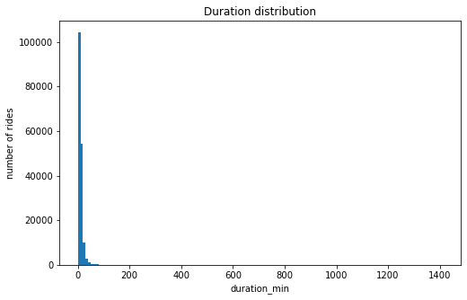

```python
# start with a histogram of the duration
# we convert the duration in seconds to minutes to make meaningful analysis
ford['duration_min'] = ford['duration_sec']/60
binsize = 10
bins = np.arange(0, ford['duration_min'].max()+binsize, binsize)
def histogram(plt, title, xLabel):
    """ Insert the title and x varible into the function to create the chart"""
    plt.figure(figsize=[8, 5])
    plt.hist(data = ford, x = xLabel, bins = bins)
    plt.xlabel(xLabel)
    plt.ylabel('number of rides')
    plt.title(title)

histogram(plt, 'Duration distribution','duration_min')
plt.show()
```

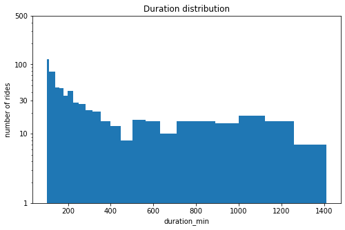

```python
# polishing
# there's a long tail in the distribution, so we put x and y on a logscale
log_binsize = 0.05
bins = 10 ** np.arange(2.0, np.log10(ford['duration_min'].max()) + log_binsize, log_binsize)

histogram(plt, 'Duration distribution','duration_min')
plt.yscale('log')
y_tick = [1,10,30,100,500]
plt.yticks(y_tick, y_tick)
plt.show()
```

Next up, the first predictor variable of interest: Gender.

### What is the share of Gender in the data?

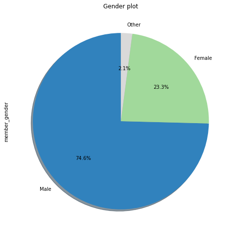

```python
# plotting gender
plt.figure(figsize=[11.69, 8.27])
ford['member_gender'].value_counts().plot(kind='pie',autopct='%1.1f%%', colormap='tab20c', shadow=True, startangle=90);
plt.title('Gender plot');
```

> In this case, gender was plotted on a pie chart and it revealed that almost 75% of the members were males, 23% females and 2% identified as another gender

Next up, the other predictor variable of interest: User Type.

### What is the percentage of Subscribers and Customers who went on trips?

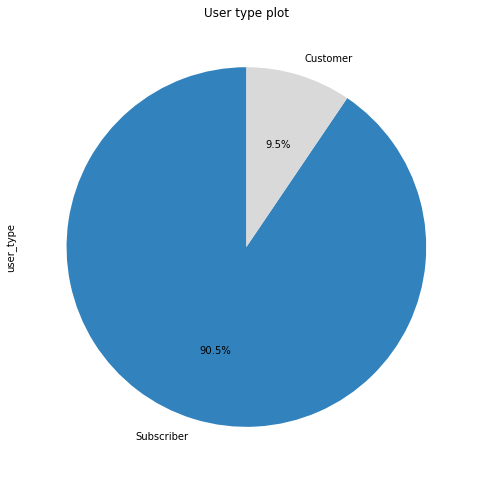

```python
# plotting user_type
plt.figure(figsize=[11.69, 8.27])
ford['user_type'].value_counts().plot(kind='pie', colormap='tab20c', autopct='%1.1f%%', shadow=None, startangle=90);
plt.title('User type plot');
```

> 90.5% of the users are subsribers with only 9.5% being customers

```python
# convert weekday into ordered categorical types

day_name = {'weekday_start': ["Monday","Tuesday","Wednesday","Thursday","Friday","Saturday","Sunday"]}
ordered_var = pd.api.types.CategoricalDtype( ordered = True, categories = day_name['weekday_start'])
ford['weekday_start'] = ford['weekday_start'].astype(ordered_var)
```

### How are rides distributed per day?

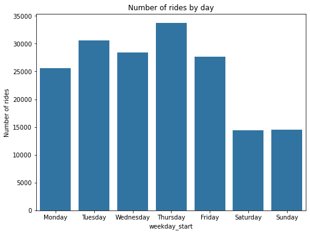

```python
# ploting to find the day with the most rides
base_color = sb.color_palette()[0]
plt.figure(figsize=[8, 6])

sb.countplot(data=ford, x='weekday_start', color= base_color);
plt.title('Number of rides by day')
plt.ylabel('Number of rides')
plt.show()
```

> Thursday recorded the day with the most rides whiles fewer people started their trips on Saturday and Sunday

### How are rides distributed per hour in a day?

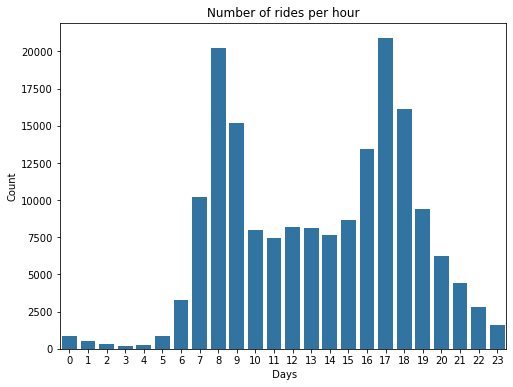

```python
hr_order = np.arange(0,24)
base_color = sb.color_palette()[0]
plt.figure(figsize=[8, 6])
sb.countplot(data=ford, x='start_hour', order=hr_order, color= base_color);
plt.title('Number of rides per hour')
plt.ylabel('Count')
plt.xlabel(' Days')
plt.show()
```

> The data is bimodal. More people started their trips at 17:00 (5:00 pm) followed closely by 8:00 am

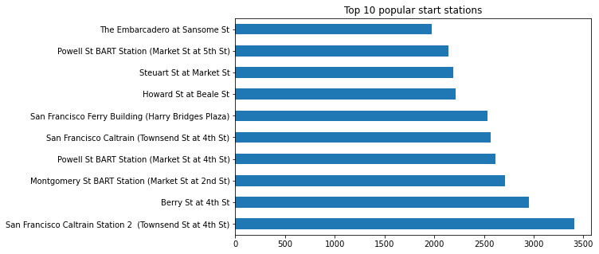

```python
def top10(plt, title, xLabel):
    """ Insert the title and x varible into the function to create the chart"""
    plt.figure(figsize=[8, 5])
    ford[xLabel].value_counts().iloc[1:11].plot(kind='barh');
    plt.title(title);

top10(plt,'Top 10 popular start stations','start_station_name')
```

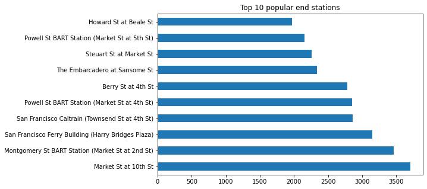

```python
top10(plt,'Top 10 popular end stations','end_station_name')
```

> There are some very common station names which might be favorites when bike rides are concerned, since they are in both top 10 popular start and end stations extract. A few are Berry St at 4th, San Francisco Caltrian, Montgomery St BART station, etc.

[figure not shown]

```python
def last10(plt, title, xLabel):
    """ Insert the title and x varible into the function to create the chart"""
    plt.figure(figsize=[8, 5])
    ford[xLabel].head(10).value_counts(ascending=True).plot(kind='barh', color='black');
    plt.title(title)

last10(plt,'Top 10 least popular start stations','start_station_name')
```

[figure not shown]

```python
last10(plt,'Top 10 least popular end stations','end_station_name')
```

### What is the Age distribution?

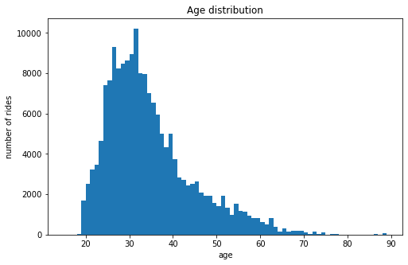

```python
plt.figure(figsize=[ 11.69, 8.27])
binsize = 1
bins = np.arange(15, ford['age'].max()+binsize, binsize)
histogram(plt, 'Age distribution','age');
```

> Majority of the riders are between the ages of 20 and 40 and it is right skewed. With a few older people as well

## Bivariate Exploration

### Exploring relationship between User type and duration of trip

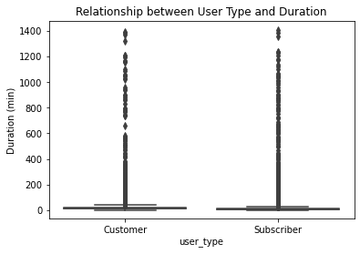

```python
def boxnwisk(plt,title,xaxis):
    """This is to make  box plot. Just input the plot title and x  variables"""
    base_color = sb.color_palette()[0]
    sb.boxplot(data = ford, x = xaxis, y = 'duration_min', color = base_color)
    plt.xlabel(xaxis)
    plt.ylabel('Duration (min)')
    plt.title(title)

boxnwisk(plt, 'Relationship between User Type and Duration','user_type')
plt.show()
```

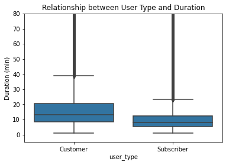

```python
# polishing it
boxnwisk(plt, 'Relationship between User Type and Duration','user_type')

plt.ylim([-5, 80])
plt.show()
```

### Exploring relationship between Gender and duration of trip

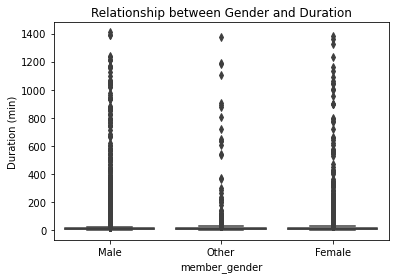

```python
boxnwisk(plt, 'Relationship between Gender and Duration','member_gender')
plt.show()
```

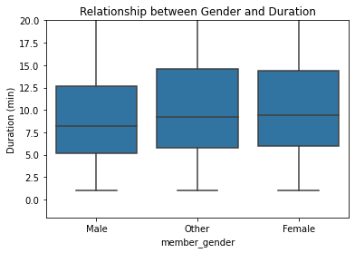

```python
#polishing it
boxnwisk(plt, 'Relationship between Gender and Duration','member_gender')
plt.ylim([-2, 20])
plt.show()
```

> Also, in the initial plot here, we see that there was a very wide spread of the data making it very difficult to read, hence we trim the duration to a max of 20 minutes and it revealed that though male riders are more than other and female, we can see that higher porportion of female and other gender trips are longer than male trips.

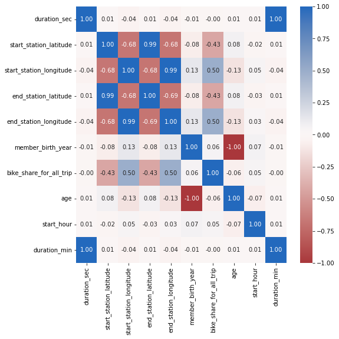

```python
plt.figure(figsize = [8, 8])

sb.heatmap(ford.corr(), annot = True, fmt = '.2f', cmap = 'vlag_r', center = 0);
```

> The heatmap above shows no realstrong relationship between the significant variables in the data set, hence we need to probe further

### Relationship between age and Duration

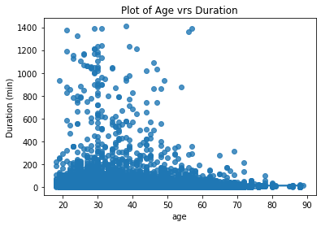

```python
sb.regplot(data = ford, x = 'age', y = 'duration_min')
plt.ylabel('Duration (min)')
plt.title('Plot of Age vrs Duration')
plt.show()
```

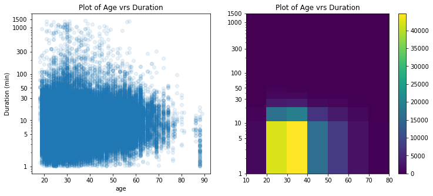

```python
# polishing the data
plt.figure(figsize = [12, 5])
plt.subplot(1, 2, 1)
sb.regplot(data = ford, x = 'age', y = 'duration_min', fit_reg=False, scatter_kws={'alpha' : 1/10})
plt.yscale('log')
plt.yticks([1,5,10,30,50,100,300,1000,1500], [1,5,10,30,50,100,300,1000,1500])
plt.ylabel('Duration (min)')
plt.title('Plot of Age vrs Duration')

plt.subplot(1,2,2)
bins_y = np.arange(1, 1500+10, 10)
bins_x = np.arange(10, 85+1, 10)
plt.yscale('log')
plt.yticks([1,5,10,30,50,100,300,1000,1500], [1,5,10,30,50,100,300,1000,1500])
plt.hist2d(ford['age'], ford['duration_min'],bins = [bins_x, bins_y])
plt.colorbar();
plt.title('Plot of Age vrs Duration')
plt.show()
```

> From the plot, there is no clear relationship between Age and Duration of trips/ rides except that the graph tells us majority of the riders were young and almost all of them went for very short duration trips i.e, less than 30 minutes

### Highest times during the day user types go out for trips

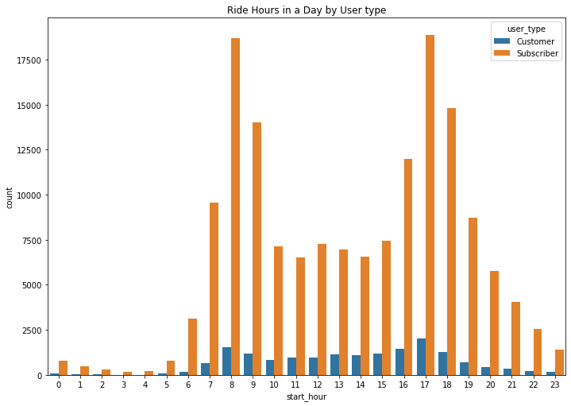

```python
plt.figure(figsize=(11.69,8.27))

plt.title('Ride Hours in a Day by User type')
sb.countplot(data=ford, x='start_hour', hue='user_type')
plt.xlabel=('Hour')
```

> It is obvious More subscribers went on rides than customers, also the distribution of the customers mimicked that of the subsribers in the senses that they also got peak rides at 8:00 and 17:00 and decreased when they decreased

### Gender and the times they go for bike rides

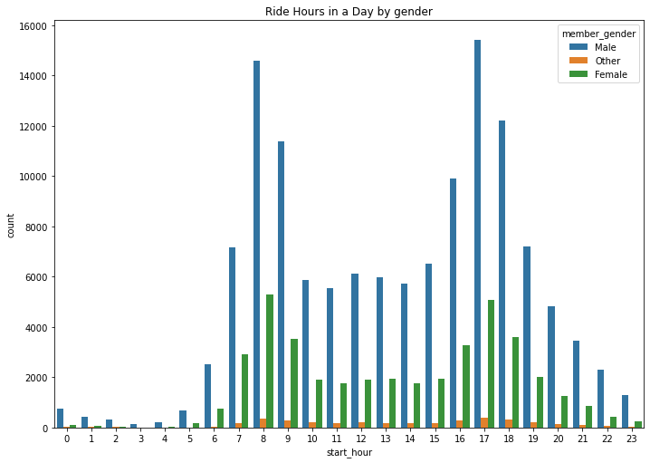

```python
plt.figure(figsize=(11.67,8.27))

plt.title('Ride Hours in a Day by gender')
sb.countplot(data=ford, x='start_hour', hue='member_gender')
plt.xlabel=('Hour')
```

> Similarly, Male and Female distributions looked alike except for the huge variation in the number of rides by males

### Day of week , User type, gender and Bike share

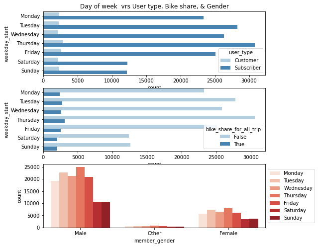

```python
# since there's only three subplots to create, using the full data should be fine.
plt.figure(figsize = [8, 8])

# subplot 1: gender vs user_type
plt.subplot(3, 1, 1)
sb.countplot(data = ford, y = 'weekday_start', hue = 'user_type', palette = 'Blues')
plt.title('Day of week  vrs User type, Bike share, & Gender')

# subplot 2: gender vs. bike_share_for_all_trip
plt.subplot(3, 1, 2)
sb.countplot(data = ford, y = 'weekday_start', hue = 'bike_share_for_all_trip', palette = 'Blues')

# subplot 2: gender vs. day of the week
plt.subplot(3, 1, 3)
sb.countplot(data = ford, x = 'member_gender', hue = 'weekday_start', palette = 'Reds')
plt.legend(loc='center left', bbox_to_anchor=(1, 0.5))
plt.show()
```

> Most subscribers likes to start trips on Thursdays followed by Tuesdays but Customers liked to start Trips on Thursdays followed by Friday. also both men, women andother genders went out for trips mostly on Thursdays

## Multivariate Exploration

The main thing I want to explore in this part of the analysis is how the three variables(i.e. Gender, Week start day, start hour) relates with the duration of the trips/ rides.

#### Which gender averagely spends more time on trips?

### Gender daily duration

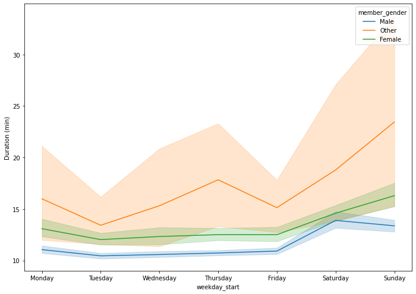

```python
plt.figure(figsize=[ 11.69, 8.27])
sb.lineplot(x=ford['weekday_start'], y=ford['duration_min'], hue=ford['member_gender']);
plt.ylabel('Duration (min)');
```

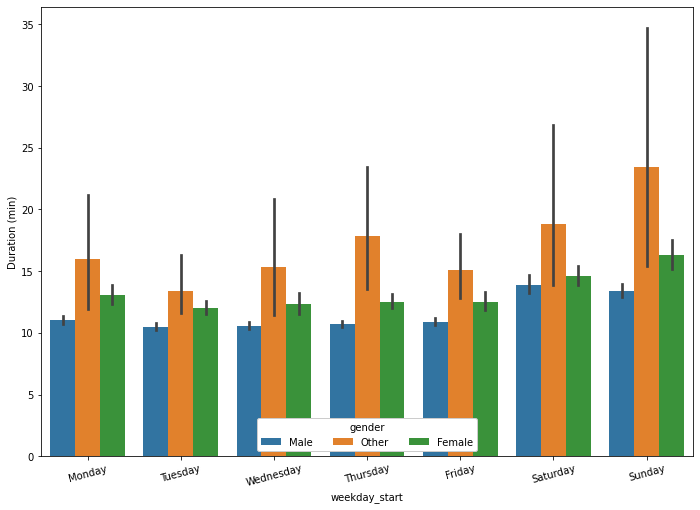

```python
plt.figure(figsize=[ 11.69, 8.27])
ax = sb.barplot(data = ford, x = 'weekday_start', y = 'duration_min', hue = 'member_gender');
ax.legend(loc = 8, ncol = 3, framealpha = 1, title = 'gender');
plt.xticks(rotation=15);
plt.ylabel('Duration (min)');
```

> Averagely, the Other gender had more duration for each day than Males and Females.\ This I believe is as a result of the huge number of males and females with a lot of the going for shorter durations.\ Also, there is a spike in duration for other and females on the weekends

#### How about specific times?

### Gender Hourly duration

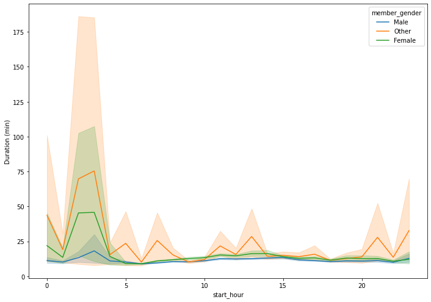

```python
plt.figure(figsize=[ 11.69, 8.27])
sb.lineplot(x=ford['start_hour'], y=ford['duration_min'], hue=ford['member_gender']);
plt.ylabel('Duration (min)')
```

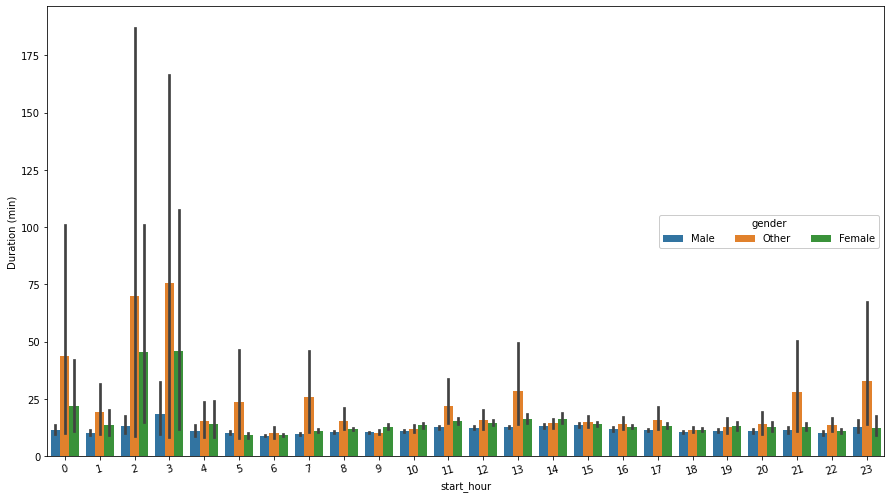

```python
plt.figure(figsize=[ 15, 8.27])
ax = sb.barplot(data = ford, x = 'start_hour', y = 'duration_min', hue = 'member_gender');
ax.legend(loc = 7, ncol = 3, framealpha = 1, title = 'gender');
plt.xticks(rotation=15);
plt.ylabel('Duration (min)');
```